# ER014 Session 1

Anastasija Tetereva, PhD & Prof. Dr. Jörg Schoder

2023-02-23

## Vergleich zweier (unabhängiger) Populationsmittelwerte

### ZixIt Corp. gegen Visa USA Inc.

Das National Law Journal (26. August bis 2. September 2002) berichtete über ein interessantes Gerichtsverfahren, an dem die ZixIt Corp. beteiligt war, ein neu gegründetes Internet-Kreditkartenabrechnungszentrum. ZixIt behauptete, dass sein neues Online-Kreditkartenverarbeitungssystem es Internetkäufern ermöglichen würde Einkäufe zu tätigen, ohne ihre Kreditkartennummern preiszugeben. Diese Behauptung verstieß gegen die etablierten Protokolle der meisten großen Kreditkartenunternehmen, einschließlich Visa. Ohne Wissen des Unternehmens begann ein Visa-Vizepräsident für technologische Forschung und Entwicklung, E-Mails und Website-Postings auf einem Yahoo!-Nachrichtenbrett für ZixIt-Investoren zu verfassen, in denen er die Behauptung von ZixIt anzweifelte und die Investoren aufforderte, ihre ZixIt-Aktien zu verkaufen. Die Visa-Führungskraft veröffentlichte mehr als 400 E-Mails und Notizen, bevor sie erwischt wurde. Als sich herausstellte, dass eine Visa-Führungskraft für die Postings verantwortlich war, reichte ZixIt eine Klage gegen die Visa Corp. ein und behauptete, dass Visa - mit Hilfe der Führungskraft als Agent - ein “bösartiges zweiteiliges Schema zur Verunglimpfung und Beeinträchtigung von ZixIt” und dessen Bemühungen um die Vermarktung des neuen Online-Kreditkartenabwicklungssystems betrieben habe. In der Verleumdungsklage forderte ZixIt 699 Millionen Schadenersatz. Die Dallas-Anwälte Jeff Tillotson und Mike Lynn von der Anwaltskanzlei Lynn, Tillotson & Pinker wurden mit der Verteidigung von Visa in dem Prozess beauftragt. Die Anwälte wiederum beauftragten Dr. James McClave als Statistikexperten. McClave sagte vor Gericht über eine von ihm durchgeführte “Ereignisstudie” aus, in der er die E-Mail-Postings der Visa-Führungskraft mit der Entwicklung des Aktienkurses von ZixIt am nächsten Arbeitstag verglich. McClaves Aussage, die zeigte, dass der Aktienkurs an gleich vielen Tagen nach einem Posting stieg wie fiel, half den Visa-Anwälten, sich in dem Fall durchzusetzen. Das National Law Journal berichtete, dass die Geschworenen nach zweieinhalbtägigen Beratungen zu dem Schluss kamen, dass [der Visa-Manager] nicht im Rahmen seines Arbeitsverhältnisses gehandelt hatte und dass Visa ZixIt nicht verleumdet oder in dessen Geschäft eingegriffen hatte.

Die Daten wurden täglich vom 1. September bis zum 30. Dezember 1999 (ein Zeitraum von 83 Tagen) erhoben und sind in der Datei `ZIXVSA.txt` verfügbar. Neben dem täglichen Schlusskurs (in Dollar) der ZixIt-Aktie enthält die Datei eine Variable, die angibt, ob die Visa-Führungskraft eine E-Mail versandt hat oder nicht, sowie die Kursänderung der Aktie am folgenden Arbeitstag. Während des 83-tägigen Zeitraums hat die Führungskraft an 43 Tagen eine E-Mail gepostet und an 40 Tagen keine Postings getätigt.

Wenn sich die täglichen Postings der Visa-Führungskraft negativ auf die ZixIt-Aktie auswirkten, müsste die durchschnittliche Kursänderung nach den Tagen, an denen keine Postings erfolgten, die durchschnittliche Kursänderung nach den Tagen mit Postings übersteigen. Eine Möglichkeit, die Daten zu analysieren, besteht daher darin einen Vergleich zweier Mittelwerte der Grundgesamtheit entweder durch ein Konfidenzintervall oder einen Hypothesentest durchzuführen. Dabei soll $\mu_1$ die mittlere Kursveränderung der ZixIt-Aktie nach allen Tagen **ohne** Email-Versand und $\mu_2$ die mittlere Kursveränderung der ZixIt-Aktie nach Tagen **mit** Email-Versand darstellen. Wenn die von ZixIt erhobenen Vorwürfe tatsächlich zutreffen, dann ist m1 größer als m2. Wenn die Daten jedoch die Behauptung von ZixIt nicht stützen, dann können wir die Nullhypothese $H_0: \mu_1-\mu_2 = 0$ nicht zugunsten von $H_1 zurückweisen: \mu_1 - \mu_2 >0$. Ähnlich verhält es sich, wenn ein Konfidenzintervall für $\mu_1-\mu_2$ den Wert 0 abdeckt, dann gibt es keinen Beweis für die Behauptung von ZixIt. Da beide Stichprobengrößen ($n_1 = 40$ und $n_2 = 43$) groß sind, können wir den $z$-Test für große Stichproben oder das Verfahren für große Konfidenzintervalle für unabhängige Stichproben anwenden.

```r
my_in_file <- "ZIXVSA.txt"
visa.data <- read.delim(xfun::from_root('data','raw',my_in_file))

summary(visa.data)
```

```
##  Trading.Day        Closing.Price     Posting           NextDayPrice
##  Length:84          Min.   :24.38   Length:84          Min.   :24.38
##  Class :character   1st Qu.:30.59   Class :character   1st Qu.:30.56
##  Mode  :character   Median :37.72   Mode  :character   Median :37.00
##                     Mean   :39.18                      Mean   :39.19
##                     3rd Qu.:44.91                      3rd Qu.:45.06
##                     Max.   :65.62                      Max.   :65.62
##                                                        NA's   :1
##      Change          Up.Down           VolumeAfter
##  Min.   :-8.7500   Length:84          Min.   : 153300
##  1st Qu.:-1.5000   Class :character   1st Qu.: 344450
##  Median :-0.1250   Mode  :character   Median : 554500
##  Mean   :-0.0354                      Mean   : 646607
##  3rd Qu.: 1.2190                      3rd Qu.: 857850
##  Max.   :11.8120                      Max.   :2384500
##  NA's   :1                            NA's   :1
```

```r
#install.packages("psych");
library(psych)
describe(visa.data)
```

```
##               vars  n      mean        sd    median   trimmed       mad
## Trading.Day*     1 84     42.50     24.39     42.50     42.50     31.13
## Closing.Price    2 84     39.18     10.19     37.72     38.06     10.61
## Posting*         3 84      2.50      0.53      3.00      2.51      0.00
## NextDayPrice     4 83     39.19     10.25     37.00     38.05     10.38
## Change           5 83     -0.04      2.86     -0.12     -0.07      2.13
## Up.Down*         6 84      2.44      0.52      2.00      2.44      0.00
## VolumeAfter      7 83 646607.23 387836.37 554500.00 599086.57 329137.20
##                     min        max      range  skew kurtosis       se
## Trading.Day*       1.00      84.00      83.00  0.00    -1.24     2.66
## Closing.Price     24.38      65.62      41.25  0.78    -0.15     1.11
## Posting*           1.00       3.00       2.00 -0.24    -1.41     0.06
## NextDayPrice      24.38      65.62      41.25  0.77    -0.18     1.12
## Change            -8.75      11.81      20.56  0.54     3.40     0.31
## Up.Down*           1.00       3.00       2.00 -0.01    -1.45     0.06
## VolumeAfter   153300.00 2384500.00 2231200.00  1.64     4.37 42570.57
```

```r
describeBy(visa.data$Change, visa.data$Posting)
```

```
##
##  Descriptive statistics by group
## group:
##    vars n mean sd median trimmed mad min  max range skew kurtosis se
## X1    1 0  NaN NA     NA     NaN  NA Inf -Inf  -Inf   NA       NA NA
## ------------------------------------------------------------
## group: NO
##    vars  n  mean   sd median trimmed  mad   min   max range skew kurtosis   se
## X1    1 40 -0.13 3.46   0.02    -0.1 2.64 -8.75 11.81 20.56 0.44     2.38 0.55
## ------------------------------------------------------------
## group: POST
##    vars  n mean  sd median trimmed  mad   min max range skew kurtosis   se
## X1    1 43 0.06 2.2  -0.25   -0.09 1.85 -4.62 7.5 12.12 0.87     1.75 0.34
```

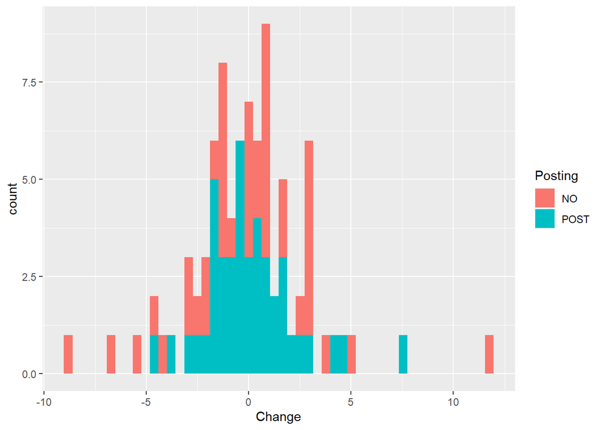

```r
visa.data %>% ggplot(aes(x = Change, fill = Posting)) + geom_histogram(bins = 50)
```

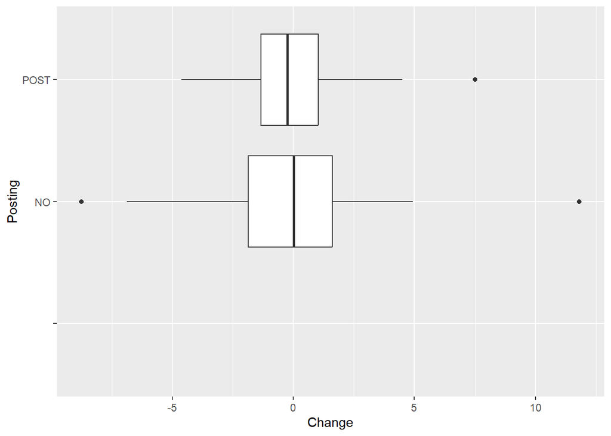

```r
visa.data %>% ggplot(aes(x = Change, y = Posting)) +
  geom_boxplot()
```

```r
t.test(Change ~ Posting, data = visa.data, alternative = "greater")
```

```
##
##  Welch Two Sample t-test
##
## data:  Change by Posting
## t = -0.29308, df = 65.205, p-value = 0.6148
## alternative hypothesis: true difference in means between group NO and group POST is greater than 0
## 95 percent confidence interval:
##  -1.258713       Inf
## sample estimates:
##   mean in group NO mean in group POST
##        -0.13282500         0.05523256
```

### Nonparametric test for comparing two population means (bootstrap)

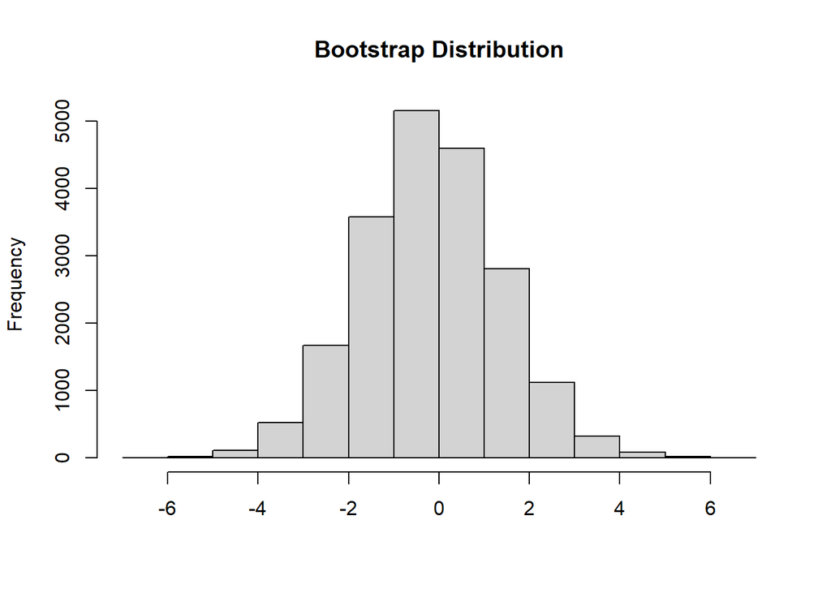

```r
Boot.runs <- 20000 # number of Bootstrap runs

visa.data.with.post <- visa.data  %>%
                       filter(Posting == "POST")

visa.data.without.post <- visa.data  %>%
                          filter(Posting == "NO")

n.yes <- length(visa.data.with.post)
n.no <- length(visa.data.without.post)

boot.samples.yes = matrix(sample(visa.data.with.post$Change, size = Boot.runs * n.yes,
                              replace = TRUE),
                              Boot.runs, n.yes)
boot.samples.no = matrix(sample(visa.data.without.post$Change, size = Boot.runs * n.no,
                              replace = TRUE),
                              Boot.runs, n.no)

test.statistics <- apply(boot.samples.no,1,mean) - apply(boot.samples.yes,1,mean)

hist(test.statistics, main = "Bootstrap Distribution", xlab = "")
```

```r
quantile(test.statistics, c(0.025, 0.975))
```

```
##      2.5%     97.5%
## -3.187286  2.883857
```

### Nichtparametrischer Test für den Vergleich zweier Populationsmittelwerte (Permutationstest)

#Permutationstest Um Ergebnisse in Experimenten zu vergleichen, wird häufig der Student’s $t$-Test verwendet. Er setzt voraus, dass die Daten zufällig aus der Grundgesamtheit ausgewählt wurden, in großen Stichproben (>30) vorliegen oder normalverteilt sind und die Varianzen zwischen den Gruppen gleich sind. Wenn diese Annahmen nicht erfüllt sind, können wir einen der Simulationstests verwenden. Zum Beispiel den Permutationstest.

Anstatt eine zugrundeliegende Verteilung anzunehmen, baut der Permutationstest seine eigene Verteilung auf, indem er die Assoziationen zwischen oder unter den Gruppen aufbricht. Oft sind wir an der Differenz der Mittelwerte oder Mediane zwischen den Gruppen interessiert, und die Nullhypothese lautet, dass es hier keinen Unterschied gibt. Wir können uns die Frage stellen: Wie extrem würden unsere Daten unter allen möglichen Permutationen aussehen? Alle möglichen Permutationen würden eine theoretische Verteilung darstellen. In der Praxis ist es nicht notwendig, ALLE Permutationen durchzuführen, um die theoretische Verteilung zu erstellen, sondern eine angemessene Anzahl von Simulationen durchzuführen, um eine Stichprobe aus dieser Verteilung zu ziehen.

Der Permutationstest ist ein leistungsfähiges Instrument zur Messung von Effekten in Experimenten. Er ist einfach zu implementieren und beruht nicht auf vielen Annahmen wie andere Tests. Er war nicht sehr beliebt, bis die Simulation auf Computern routinemäßig eingeführt wurde.

Er ist eng mit einem anderen Simulationstest verwandt: dem Bootstrapping-Hypothesentest, bei dem die Stichproben mit Ersatz gezogen werden.

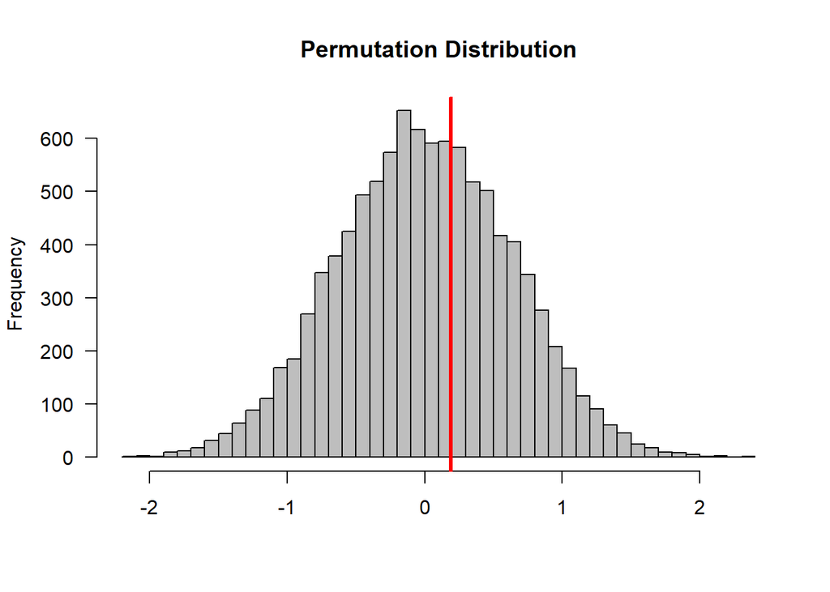

```r
permutation.test <- function(treatment, outcome, n){
  data <- na.omit(data.frame(treatment, outcome))
  treatment <- data[,1]
  outcome <- data[,2]
  distribution=c()
  result=0
  for(i in 1:n){

    distribution[i]= diff(by(outcome, sample(treatment, length(treatment), FALSE), mean))
  }
  original <- diff(by(outcome, treatment, mean))
  return(list(distribution, original))
}

treatment <- visa.data$Posting
outcome <-  visa.data$Change
test.statistics.permut <- permutation.test(visa.data$Posting, visa.data$Change, 10000)
hist(test.statistics.permut[[1]], breaks=50, col='grey', main="Permutation Distribution", las=1, xlab='')
abline(v=test.statistics.permut[[2]], lwd=3, col="red")
```

```r
quantile(test.statistics.permut[[1]], c(0.025, 0.975))
```

```
##      2.5%     97.5%
## -1.233945  1.210502
```

Wir führen eine Simulation durch, bei der 10k Shaffles ohne Ersatz gezogen werden, und zeichnen die Differenz der Mittelwerte für jede Permutation auf. Dann konstruieren wir Konfidenzintervalle für den Mittelwertunterschied unter der Nullhypothese, dass es keinen Unterschied im Mittelwert der Veränderung gibt. Wenn wir die Verteilung aufzeichnen, können wir feststellen, dass unsere ursprüngliche Differenz nicht besonders extrem ist, mit einem exakten $p$-Wert von ? (wir haben uns die Konfidenzintervalle angesehen, versuchen Sie jetzt, den $p$-Wert zu berechnen). Wenn wir diesen $p$-Wert mit dem des $t$-Tests vergleichen, was stellen wir dann fest?

```r
#install.packages("coin")
library(coin)
visa.data$Posting = as.factor(visa.data$Posting )
oneway_test(Change~Posting,data=visa.data,distribution="exact")
```

```
##
##  Exact Two-Sample Fisher-Pitman Permutation Test
##
## data:  Change by Posting (NO, POST)
## Z = -0.29935, p-value = 0.7697
## alternative hypothesis: true mu is not equal to 0
```

### Ermittlung eines geeigneten Stichprobenumfangs

Sie können den geeigneten Stichprobenumfang ermitteln, um die Differenz zwischen einem Paar von Parametern mit einem bestimmten Stichprobenfehler (SE) und Zuverlässigkeitsgrad zu schätzen. Zur Schätzung der Differenz zwischen einem Paar von Parameter mit dem gegebenen Konfidenzniveau innerhalb der SE-Einheiten zu korrigieren.

Betrachten Sie das folgende Problem. Neue Düngemittel werden oft mit dem Versprechen höherer Ernteerträge beworben. Ernteerträgen beworben. Angenommen, wir wollen den mittleren Ertrag $m_1$ von Weizen bei Verwendung eines neuen Düngemittels mit dem mittleren Ertrag $m_2$ bei Verwendung eines herkömmlichen Düngemittels vergleichen. Die Schätzung des Unterschieds im mittleren Ertrag pro Acker soll mit einer Genauigkeit von $.25$ Scheffel bei einem Konfidenz Vertrauenskoeffizient von $.95$. Wenn die Stichprobengrößen gleich sein sollen, bestimmen Sie $n_1 = n_2 = n$, die Anzahl der 1-Hektar-Weizenparzellen, die jedem Dünger zugeordnet sind.

Um das Problem zu lösen, müssen Sie etwas über die Variation in des Scheffelertrags pro Hektar wissen. Angenommen, Sie wissen aus früheren Aufzeichnungen, dass die Erträge von Weizen eine Schwankungsbreite von etwa 10 Scheffel pro Hektar aufweisen. Dann könnte man folgende Näherung aufstellen $\sigma_1 = \sigma_2 = \sigma$, indem man die Spanne gleich $4 \sigma$ lässt. Wir wissen, dass $z_{\alpha/2}\sigma_{\overline{x}_1-\overline{x}_2} = SE$ ist. Auf diese Weise wird $z_{\alpha/2}\sqrt{\frac{\sigma_1^2}{n_1} +\frac{\sigma_2^2}{n_2}} = SE$ und $1.96 \sqrt{\frac{2 (2.5)^2}{n}} = 0.25$ und $n = 769$.

### Vergleich zweier Bevölkerungsanteile

Wir haben gezeigt, wie der Statistikexperte einen Vergleich von zwei Mittelwerten verwendet, um Visa in einem Verleumdungsfall zu verteidigen. Wir erinnern uns, dass ZixIt behauptete, dass die E-Mail-Postings eines Visa-Managers einen negativen Einfluss auf den Versuch von ZixIt gehabt hätten, ein neues Online-Kreditkartenverarbeitungssystem zu entwickeln. Kreditkartenabwicklungssystem zu entwickeln. Hier zeigen wir eine andere Art der Datenanalyse, die von dem Statistiker erfolgreich vor Gericht präsentiert wurde. Neben dem täglichen Schlusskurs und dem Handelsvolumen der ZixIt-Aktie enthält die Datei `ZIXVSA.txt` auch eine qualitative Variable, die angibt, ob der Aktienkurs an einem Tag gestiegen ist oder nicht (gesunken oder gleich geblieben) am Folgetag ist. Diese Variable wurde vom Statistiker erstellt, um den Anteil der Tage zu vergleichen, an denen die ZixIt-Aktie an Tagen **mit** bzw. **ohne** Email-Versand gestiegen ist. $p_1$ sei der Anteil der Tage, an denen der Kurs der ZixIt-Aktie nach allen Tagen **ohne** Email-Versand gestiegen ist, und $p_2$ sei der Anteil der Tage, an denen der Kurs der ZixIt Aktienkurs nach Tagen **mit** Email-Versand gestiegen ist. Wenn die von ZixIt erhobenen Vorwürfe wahr wären (d.h., dass die Email-Postings einen negativen Einfluss auf die ZixIt-Aktie hatten), wird $p_1$ größer sein als $p_2$. Daher ist ein Vergleich von zwei Populationsanteilen angebracht. Erinnern wir uns, dass während des 83-Tage-Zeitraums an 43 Tagen E-Mails versendet und an 40 Tagen keine Emails versendet wurden. Nochmals, beide Stichprobenumfänge ($n_1 = 40$ und $n_2 = 43$) sind groß, so dass wir den $z$-Test für große Stichproben anwenden können oder das Verfahren des großen Konfidenzintervalls für unabhängige Stichproben anwenden.

```r
#table(visa.data$Up.Down,visa.data$Posting)
prop.test(length(visa.data$Up.Down[visa.data$Up.Down=="UP"]), nrow(visa.data), p = 0.5, alternative = "two.sided")
```

```
##
##  1-sample proportions test with continuity correction
##
## data:  length(visa.data$Up.Down[visa.data$Up.Down == "UP"]) out of nrow(visa.data), null probability 0.5
## X-squared = 0.58333, df = 1, p-value = 0.445
## alternative hypothesis: true p is not equal to 0.5
## 95 percent confidence interval:
##  0.3447862 0.5643684
## sample estimates:
##        p
## 0.452381
```

## Vergleich zweier abhängiger Populationsmittelwerte

Angenommen, Sie möchten die mittleren Tagesumsätze zweier Restaurants in derselben Stadt vergleichen. Wenn Sie den Gesamtumsatz der Restaurants für jeden der 12 zufällig ausgewählten Tage während eines Zeitraums von 6 Monaten aufzeichnen, könnten die Ergebnisse wie in der Datei `restaurants.txt` aussehen.

Wir betrachten nun eine gültige Methode zur Analyse der Daten. Wir fügen die Spalte der Differenzen zwischen den täglichen Umsätzen der beiden Restaurants hinzu, $x_d = x_1 - x_2$. Wir können diese täglichen Umsatzdifferenzen als eine Zufallsstichprobe Stichprobe aller täglichen Differenzen in der Vergangenheit und Gegenwart betrachten. Anhand dieser Stichprobe können wir dann Rückschlüsse auf den Mittelwert der Grundgesamtheit der Differenzen ziehen, der gleich der Differenz $\mu_1-\mu_2$, d. h. der Mittelwert der Grundgesamtheit (und der Stichprobe) der Differenzen ist gleich der Differenz zwischen den Mittelwerten der Grundgesamtheit (und der Stichprobe).

```r
library("readxl")
my_in_file <- "SALES2.xlsx"
data.rest <- read_excel(xfun::from_root('data','raw',my_in_file))
head(data.rest)
```

```
## # A tibble: 6 × 4
##     OBS DAY   SALES1 SALES2
##   <dbl> <chr>  <dbl>  <dbl>
## 1     1 WED     1005    918
## 2     2 SAT     2073   1971
## 3     3 TUE      873    825
## 4     4 WED     1074    999
## 5     5 FRI     1932   1827
## 6     6 THR     1338   1281
```

Nun werden wir zwei Versionen des $t$-Tests durchführen. Zunächst führen wir einen $t$-Test für die Differenz zwischen den Umsätzen zweier Restaurants durch, mit der Nullhypothese, dass die Differenz gleich Null ist, und der Alternative, dass sie größer als Null ist.

```r
t.test(data.rest$SALES1-data.rest$SALES2, mu = 0, alternative = "greater")
```

```
##
##  One Sample t-test
##
## data:  data.rest$SALES1 - data.rest$SALES2
## t = 8.8799, df = 11, p-value = 1.195e-06
## alternative hypothesis: true mean is greater than 0
## 95 percent confidence interval:
##  65.41622      Inf
## sample estimates:
## mean of x
##        82
```

Zweitens führen wir einen $t$-Test für gepaarte Stichproben durch mit der Nullhypothese, dass beide Restaurants den gleichen Umsatz haben, und der Alternative, dass der Umsatz des ersten Restaurants größer ist. Vergleichen Sie die Ergebnisse der beiden Tests.

```r
t.test(data.rest$SALES1, data.rest$SALES2, paired = TRUE, alternative = "greater")
```

```
##
##  Paired t-test
##
## data:  data.rest$SALES1 and data.rest$SALES2
## t = 8.8799, df = 11, p-value = 1.195e-06
## alternative hypothesis: true mean difference is greater than 0
## 95 percent confidence interval:
##  65.41622      Inf
## sample estimates:
## mean difference
##              82
```

Als erfahrener *Data Scientist*, möchten Sie vielleicht Ihre asymptotischen Ergebnisse mit denen von Bootstrap und Permutationstest vergleichen. Bitte tun Sie das.